# Course Project

Mary Sun

Description: This document is my peer assessment write-up for the Course Project in the Practical Machine Learning Coursera course produced by Johns Hopkins University. It was built using the knitr functions in RStudio and published to HTML format.

## 2. Data exploration

This data was generated by six healthy male participants, aged 20-28, who performed one set of 10 repetitions of the Unilateral Dumbbell Biceps Curl in five different ways: according to specification (Class A), with elbows thrown to front (Class B), lifting the dumbbell halfway (Class C), lowering the dumbbell halfway (Class D), and with hips thrown to the front (Class E). Classes B-E are meant to correspond to common mistakes while performing this exercise. Participants did not have significant weight lifting experienced and were supervised by an experienced weight lifter to ensure compliance with the specifications. The dummbbell was relatively light at 1.25kg, to ensure safe and controlled movement.

### 2A. Environment preparation

The library necessary for the following analysis are loaded

```r
## Libraries
library(knitr)
library(caret)
```

```r
library(rpart)
library(rpart.plot)
library(rattle)
library(randomForest)
library(corrplot)
set.seed(12345)
```

### 2B. Data loading

Data from the specified training and testing CSV files are downloaded and stored as objects in R.

```r
## Data download
UrlTrain <- "http://d396qusza40orc.cloudfront.net/predmachlearn/pml-training.csv"
UrlTest  <- "http://d396qusza40orc.cloudfront.net/predmachlearn/pml-testing.csv"
training <- data.frame(read.csv(url(UrlTrain)))
testing  <- data.frame(read.csv(url(UrlTest)))
```

### 2C. Data partitioning

The training data is partitioned into two parts to create a Training set (80% of data) for the model selection process and a Test set (20% of data) for use in validation. Note that the testing data is not changed during this analysis and is only used for results generation.

```r
# Partition training data
inTrain  <- createDataPartition(training$classe, p=0.8, list=FALSE)
TrainSet <- training[inTrain, ]
TestSet  <- training[-inTrain, ]

#Exploring dimensions of partitioned data
dim(TrainSet)
```

```
## [1] 15699   160
```

```r
dim(TestSet)
```

```
## [1] 3923  160
```

As we can see above, both datasets have 160 variables.

### 2D. Data cleaning

First, we remove variables with close to zero variance. It is unlikely that these variables will contribute significantly to the model, since they do not vary themselves and therefore will not explain variance in our outcome of interest (“classe”).

```r
## Cleaning: remove variables with close to zero variance
NZV <- nearZeroVar(TrainSet)
TrainSet <- TrainSet[, -NZV]
TestSet  <- TestSet[, -NZV]
dim(TrainSet)
```

```
## [1] 15699   102
```

```r
dim(TestSet)
```

```
## [1] 3923  102
```

```r
# Cleaning: remove variables that are majority NA
AllNA    <- sapply(TrainSet, function(x) mean(is.na(x))) > 0.95
TrainSet <- TrainSet[, AllNA==FALSE]
TestSet  <- TestSet[, AllNA==FALSE]
dim(TrainSet)
```

```
## [1] 15699    59
```

```r
dim(TestSet)
```

```
## [1] 3923   59
```

```r
## Cleaning: remove identification only variables (columns 1 to 5)
TrainSet <- TrainSet[, -(1:5)]
TestSet  <- TestSet[, -(1:5)]
dim(TrainSet)
```

```
## [1] 15699    54
```

```r
dim(TestSet)
```

```
## [1] 3923   54
```

This step reduces the number of variables from 59 to 54.

### 2E. Correlation analysis among variables

Before proceeding to modeling, a correlation analysis is performed to see if there are many variables that are highly correlated. If so, a PCA (Principal Components Analysis) will be performed to reduce the number of variables and extract their useful features.

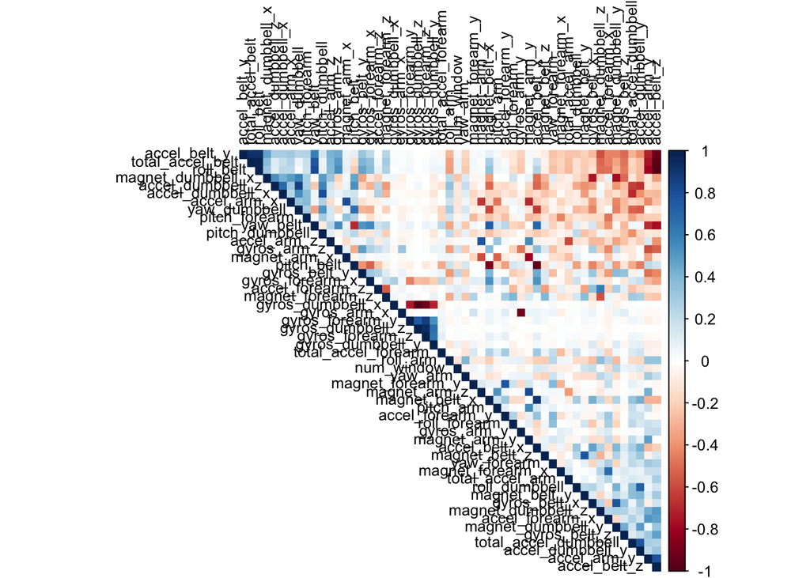

```r
## Correlation analysis among remaining variables
corMatrix <- cor(TrainSet[, -54])
corrplot(corMatrix, order = "FPC", method = "color", type = "upper",
         tl.cex = 0.8, tl.col = rgb(0, 0, 0))
```

The above plot can be interpreted using a heatmap legend, where darker colored areas indicate higher degrees of positive (blue) or negative (red) correlation as measured on the right hand side vertical axis. While there are dark areas, they are not numerous enough to warrant a PCA. Therefore, we proceed to the modeling step.

## 3. Modeling

This analysis evaluates three predictive techniques to model the regressions in the training dataset: random forests, decision trees, and the generalized boosted model (gbm). Each technique is evaluated below and a confusion matrix is included with each analysis to visualized relative accuracy.

### 3A. Modeling: Random Forests

```r
## Prediction model: random forest
set.seed(12345)
controlRF <- trainControl(method="cv", number=3, verboseIter=FALSE)
modFitRandForest <- train(classe ~ ., data=TrainSet, method="rf", trControl=controlRF)
modFitRandForest$finalModel
```

```
##
## Call:
##  randomForest(x = x, y = y, mtry = param$mtry)
##                Type of random forest: classification
##                      Number of trees: 500
## No. of variables tried at each split: 27
##
##         OOB estimate of  error rate: 0.18%
## Confusion matrix:
##      A    B    C    D    E  class.error
## A 4463    0    0    0    1 0.0002240143
## B    7 3028    2    1    0 0.0032916392
## C    0    3 2735    0    0 0.0010956903
## D    0    0   13 2560    0 0.0050524679
## E    0    0    0    2 2884 0.0006930007
```

```r
## Prediction on test data
predictRandForest <- predict(modFitRandForest, newdata=TestSet)
confMatRandForest <- confusionMatrix(table(predictRandForest, TestSet$classe))
confMatRandForest
```

```
## Confusion Matrix and Statistics
##
##
## predictRandForest    A    B    C    D    E
##                 A 1116    1    0    0    0
##                 B    0  758    2    0    0
##                 C    0    0  682    2    0
##                 D    0    0    0  640    0
##                 E    0    0    0    1  721
##
## Overall Statistics
##
##                Accuracy : 0.9985
##                  95% CI : (0.9967, 0.9994)
##     No Information Rate : 0.2845
##     P-Value [Acc > NIR] : < 2.2e-16
##
##                   Kappa : 0.9981
##
##  Mcnemar's Test P-Value : NA
##
## Statistics by Class:
##
##                      Class: A Class: B Class: C Class: D Class: E
## Sensitivity            1.0000   0.9987   0.9971   0.9953   1.0000
## Specificity            0.9996   0.9994   0.9994   1.0000   0.9997
## Pos Pred Value         0.9991   0.9974   0.9971   1.0000   0.9986
## Neg Pred Value         1.0000   0.9997   0.9994   0.9991   1.0000
## Prevalence             0.2845   0.1935   0.1744   0.1639   0.1838
## Detection Rate         0.2845   0.1932   0.1738   0.1631   0.1838
## Detection Prevalence   0.2847   0.1937   0.1744   0.1631   0.1840
## Balanced Accuracy      0.9998   0.9990   0.9982   0.9977   0.9998
```

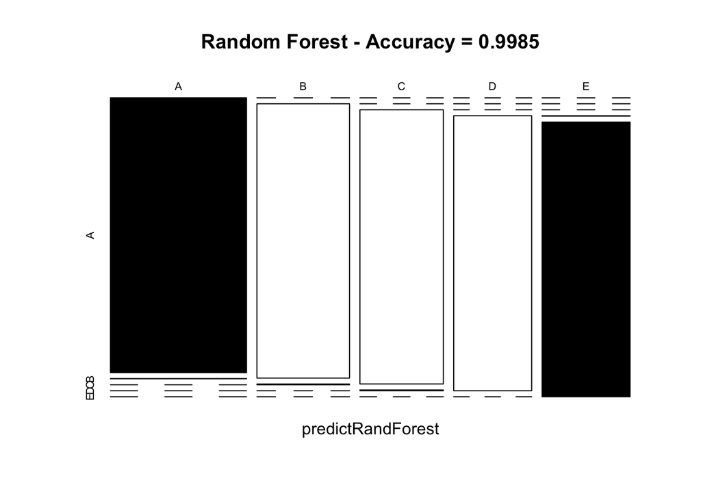

```r
## Plot results
plot(confMatRandForest$table, col = confMatRandForest$byClass, main = paste("Random Forest - Accuracy =", round(confMatRandForest$overall['Accuracy'], 4)))
```

### 3B. Modeling: Decision Trees

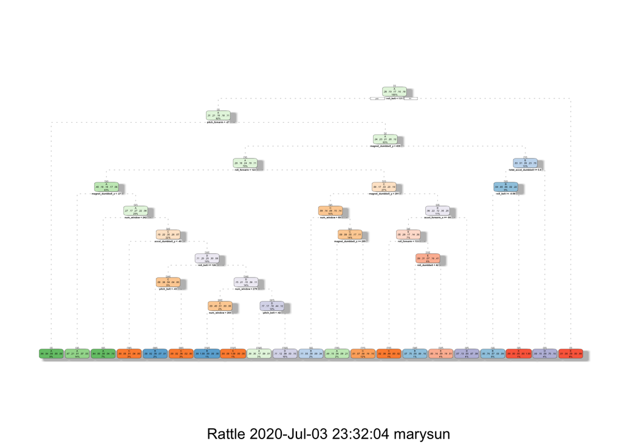

```r
## Prediction model: decision trees
set.seed(12345)
modFitDecTree <- rpart(classe ~ ., data=TrainSet, method="class")
fancyRpartPlot(modFitDecTree)
```

```r
## Prediction on test data
predictDecTree <- predict(modFitDecTree, newdata=TestSet, type="class")
confMatDecTree <- confusionMatrix(table(predictDecTree, TestSet$classe))
confMatDecTree
```

```
## Confusion Matrix and Statistics
##
##
## predictDecTree    A    B    C    D    E
##              A 1025  197   33   81   58
##              B   31  395   17   16   61
##              C    2   35  585   94   39
##              D   48  102   34  413   76
##              E   10   30   15   39  487
##
## Overall Statistics
##
##                Accuracy : 0.7405
##                  95% CI : (0.7265, 0.7542)
##     No Information Rate : 0.2845
##     P-Value [Acc > NIR] : < 2.2e-16
##
##                   Kappa : 0.6692
##
##  Mcnemar's Test P-Value : < 2.2e-16
##
## Statistics by Class:
##
##                      Class: A Class: B Class: C Class: D Class: E
## Sensitivity            0.9185   0.5204   0.8553   0.6423   0.6755
## Specificity            0.8685   0.9605   0.9475   0.9207   0.9706
## Pos Pred Value         0.7353   0.7596   0.7748   0.6137   0.8382
## Neg Pred Value         0.9640   0.8930   0.9688   0.9292   0.9300
## Prevalence             0.2845   0.1935   0.1744   0.1639   0.1838
## Detection Rate         0.2613   0.1007   0.1491   0.1053   0.1241
## Detection Prevalence   0.3553   0.1326   0.1925   0.1716   0.1481
## Balanced Accuracy      0.8935   0.7405   0.9014   0.7815   0.8230
```

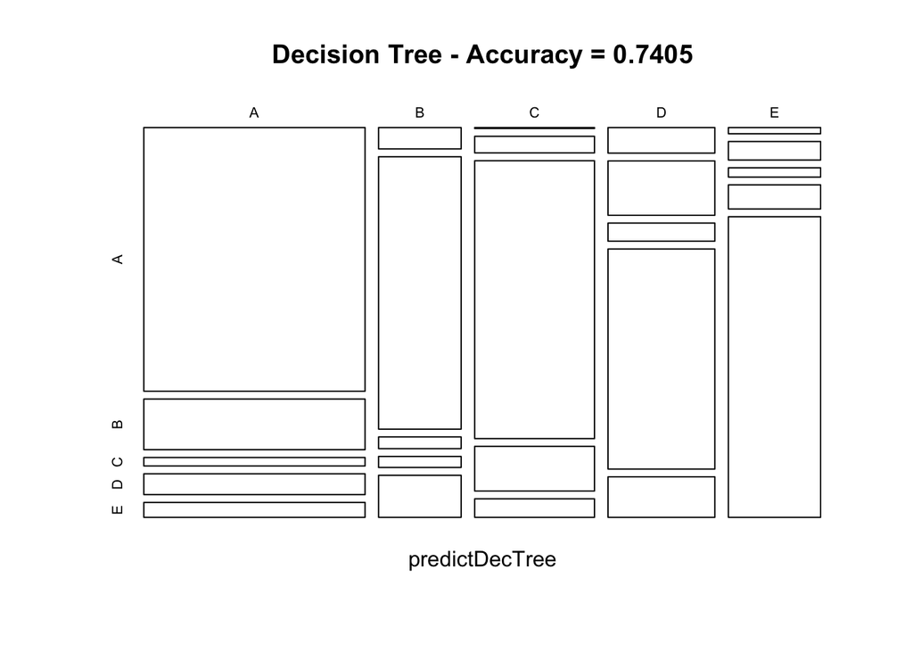

```r
## Plot results
plot(confMatDecTree$table, col = confMatDecTree$byClass,
     main = paste("Decision Tree - Accuracy =",
                  round(confMatDecTree$overall['Accuracy'], 4)))
```

### 3B. General Boosted Model (GBM)

```r
## Prediction model: general boosted model
set.seed(12345)
controlGBM <- trainControl(method = "repeatedcv", number = 5, repeats = 1)
modFitGBM  <- train(classe ~ ., data=TrainSet, method = "gbm",
                    trControl = controlGBM, verbose = FALSE)
modFitGBM$finalModel
```

```
## A gradient boosted model with multinomial loss function.
## 150 iterations were performed.
## There were 53 predictors of which 53 had non-zero influence.
```

```r
## Prediction on test data
predictGBM <- predict(modFitGBM, newdata=TestSet)
confMatGBM <- confusionMatrix(table(predictGBM, TestSet$classe))
confMatGBM
```

```
## Confusion Matrix and Statistics
##
##
## predictGBM    A    B    C    D    E
##          A 1111    5    0    2    0
##          B    5  745    5    5    5
##          C    0    8  677   13    2
##          D    0    1    2  622    6
##          E    0    0    0    1  708
##
## Overall Statistics
##
##                Accuracy : 0.9847
##                  95% CI : (0.9804, 0.9883)
##     No Information Rate : 0.2845
##     P-Value [Acc > NIR] : < 2.2e-16
##
##                   Kappa : 0.9807
##
##  Mcnemar's Test P-Value : NA
##
## Statistics by Class:
##
##                      Class: A Class: B Class: C Class: D Class: E
## Sensitivity            0.9955   0.9816   0.9898   0.9673   0.9820
## Specificity            0.9975   0.9937   0.9929   0.9973   0.9997
## Pos Pred Value         0.9937   0.9739   0.9671   0.9857   0.9986
## Neg Pred Value         0.9982   0.9956   0.9978   0.9936   0.9960
## Prevalence             0.2845   0.1935   0.1744   0.1639   0.1838
## Detection Rate         0.2832   0.1899   0.1726   0.1586   0.1805
## Detection Prevalence   0.2850   0.1950   0.1784   0.1608   0.1807
## Balanced Accuracy      0.9965   0.9876   0.9913   0.9823   0.9908
```

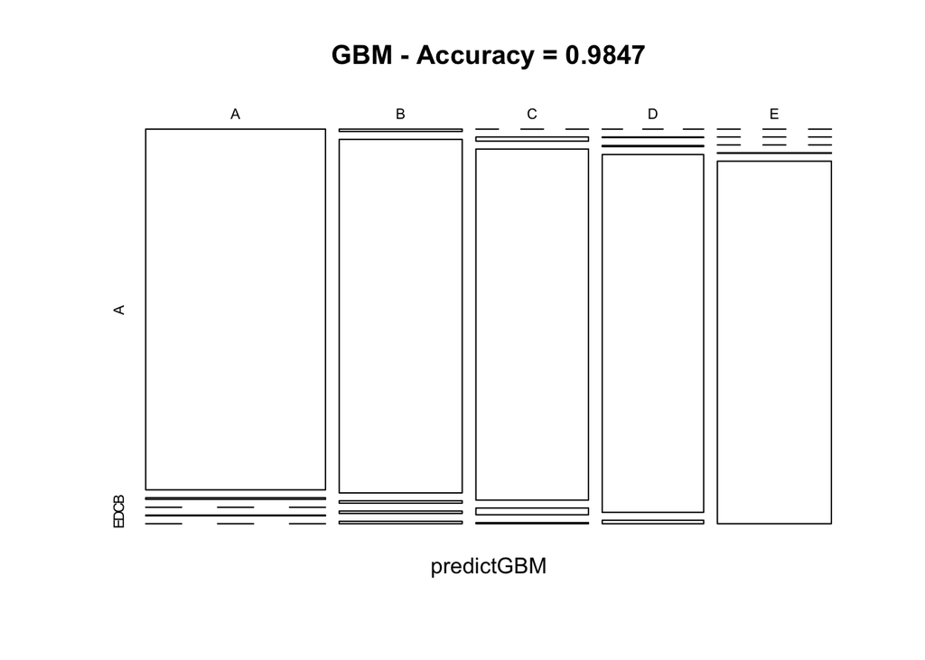

```r
## Plot results
plot(confMatGBM$table, col = confMatGBM$byClass,
     main = paste("GBM - Accuracy =", round(confMatGBM$overall['Accuracy'], 4)))
```

## 4. Model Selection

```r
## Random forest method has highest accuracy, apply it to testing dataset
predictOnTest <- predict(modFitRandForest, newdata=testing)
predictOnTest
```

```
##  [1] B A B A A E D B A A B C B A E E A B B B
## Levels: A B C D E
```